# ch07_2

Daniel_Kim

2020-04-08

```r
library(ez)
library(ggplot2)
library(nlme)
library(pastecs)
library(reshape2)
library(WRS)
library(clinfun)
library(pgirmess)
library(car)
library(tidyverse)
# install.packages('mvoutlier')
library(mvoutlier)
library(gmodels)
library(MASS)
library(nlme) # 다층모형을 위해
library(QuantPsyc)
library(boot)
# install.packages('epiDisplay')
library(epiDisplay)
library(knitr)
```

### 7.1. 이번 장에서 배우는 내용

### 7.2 회귀의 소개

- 단순회귀, 다중회귀
- 최소제곱법(method of least squares) 수학적 기법을 이용해 자료를 가장 잘 서술하는 직선을 선택

#### 7.2.1 직선에 관한 중요한 정보 몇 가지

- 기울기 $b_{1}$, 절편 $b_{0}$
- $b_{1}$, $b_{0}$들을 회귀계수라고 한다.

$$Y_{i} = (b_{0} + b_{1} X_{i}) + \epsilon_{i}$$

#### 7.2.2. 최소제곱법

- line of best fit

#### 7.2.3. 적합도 평가: 제곱합, r, $R^{2}$

- 평균 값과 관측값의 차이를 구하고, 그 차이 제곱들의 합을 총제곱합(total sum of squares)라고 한다. 총제곱합을 $SS_{T}$로 표기한다. $SS_{T}$는 관측자료와 Y의 평균값의 차이들로 계산한 값이다.
- $\sum(O_{i} - M_{i})^{2}$ 을 제곱잔차합 또는 잔차제곱합이라고 하고 $SS_{R}$로 표기한다. $SS_{R}$은 관측자료와 회귀선의 차이들로 계산한 값이다.
- $SS_{T}$와 $SS_{R}$의 차이는 평균 대신 회귀모형을 사용했을 때 예측이 얼마나 향상되었는지를 나타낸다. 다른 말로 하면 그 차이는 회귀모형을 사용했을 때 부정확도가 얼마나 줄어들 것이지를 보여준다. 이러한 향상량을 모형제곱합(model sum of squares)이라 부르고 $SS_{M}$으로 표기한다. $SS_{M}$은 Y의 평균값과 회귀선의 차이들로 이루어진다.
- $SS_{M}$의 값이 크다느 것은 결과변수의 예측을 위해 평균을 사용하는 것과 회귀모형을 사용하는 것이 많이 다르다는 뜻이다. 평균은 가장 기본적인 모형이므로, 이 값이 크다는 것은 회귀모형이 이전보다 결과변수를 훨씬 잘 예측함을 의미한다.
- $R^{2}$은 가장 기본적인 모형이 설명하는 변동의 양($SS_{T}$)에 대한, 주어진 모형이 설명하는 변동의 양($SS_{M}$)의 비를 나타낸다.

$$R^{2} = \frac{SS_{M}}{SS_{T}}$$

- $R^{2}$의 제곱근은 곧 피어슨 상관계수이다. 그런 만큼, 단순회귀에서 상관계수 $r$은 회귀모형의 전반적인 적합도를 잘 추정하는 값이며 $R^{2}$은 상관관계의 실질적인 크기를 잘 추정하는 값이다.
- $F$ 같은 검정통계량들은 체계적 변동의 양을 비체계적 변동의 양으로 나눈 것이다. 다른 말로 하면 모형과 모형의 오차를 비교한 것이다. 회귀분석에서 $F$는 $SS_{M}(모형에 의한 향상)$과 $SS_{R}(모형과 관측값의 차이)$의 비이다.
- 그런데 제곱합은 합한 차이들의 수에 의존하므로, 실제로는 평균 제곱들의 합을 사용한다. 그러한 합을 평균제곱(mean squares, MS)라고 한다. 이것은 그냥 제곱합을 자유도로 나누면 된다.
- $SS_{M}$의 자유도는 모형의 변수 개수이고 $SS_{R}$의 자유도는 회귀분석으로 추정하는 매개변수(모수) 개수를 관측값 개수에서 뺀 것이다. (이는 곧 상수를 포함한 베타 계수들의 개수이다.) 이 자유도들로 해당 제곱합을 나누면 모형의 평균제곱($MS_{M}$)과 잔차 평균제곱($MS_{R}$)이 나온다.
- $F$비는 기본모형을 사용했을 때와 비교할 때 새 모형이 결과의 예측을 얼마나 향상시키는지를 나타낸다.

$$F = \frac{MS_{M}}{MS_{R}}$$

#### 7.2.4. 개별 예측변수의 평가

- 만일 어떤 변수가 결과를 유의하게 예측한다면, 해당 $b$값이 0과는 달라야 한다. 이 가설을 $t$ 검증으로 검사할 수 있다. t-검정량은 $b$의 값이 0이라는 귀무가설을 검증한다. 따라서, 만일 그 검사의 결과가 유의하다면 해당 예측변수가 결과를 예측하는 능력에 유의하게 기여한다는 확신이 커진다.
- 우리의 관심사는 $b$가 그 추정값의 오차보다 큰 가이다. t검정은 표본 b 값들의 변동을 기준으로 할 때 모형의 b 값이 0과 조금만 달라도 의미 있는 차이로 해석할 수 있다.
- 귀무가설이 $b$가 0이라는 것이므로, 결과적으로 t 통계량은 그냥 $b$의 관측값을 해당 표준오차로 나눈 것이다.

$$t = \frac{b_{관측} - b_{기대}}{SE_{b}}$$

$$t = \frac{b_{관측}}{SE_{b}}$$

- R은 $b$가 실제로 0일때 그러한 t의 관측값(또는 그보다 더 큰 값)이 발생할 정확한 확률을 제공한다. 이 유의확률이 .05보다 작으면 과학자들은 b가 0과 유의하게 다르다고 가정하는 것이다.

```r
album1 <- read.delim('Album Sales 1.dat', header = T)
```

```r
albumSales.1 <- lm(sales ~ adverts, data =album1)
albumSales.1 %>% summary()
```

```
Call:
lm(formula = sales ~ adverts, data = album1)

Residuals:
     Min       1Q   Median       3Q      Max
-152.949  -43.796   -0.393   37.040  211.866

Coefficients:
             Estimate Std. Error t value Pr(>|t|)
(Intercept) 1.341e+02  7.537e+00  17.799   <2e-16 ***
adverts     9.612e-02  9.632e-03   9.979   <2e-16 ***
---
Signif. codes:  0 ‘***’ 0.001 ‘**’ 0.01 ‘*’ 0.05 ‘.’ 0.1 ‘ ’ 1

Residual standard error: 65.99 on 198 degrees of freedom
Multiple R-squared:  0.3346,    Adjusted R-squared:  0.3313
F-statistic: 99.59 on 1 and 198 DF,  p-value: < 2.2e-16
```

#### 7.5.1 모형의 전반적인 적합도

- Multiple R-squared: 0.3346, Adjusted R-squared: 0.3313

```r
sqrt(0.3346)
```

```
[1] 0.5784462
```

- 두 변수(sales, adverts)간의 상관계수는 .58이다.
- $R^{2}$이 .335라는 것은 광고비가 판매량 변동의 33.5%를 설명한다는 의미이다.
- F-statistic: 99.59 on 1 and 198 DF, p-value: < 2.2e-16
- $F$비와 $p-value$가 있는데, 이 결과는 $p < .001$ 수준에서 유의하다. 즉, 이 회귀모형을 이용해서 음반 판매량을 예측하는 것이 음반 판매량의 평균을 사용해서 판매량을 예측할 때보다 유의하게 더 낫다는 결론을 내릴 수 있다.

#### 7.5.2. 모형 매개변수들

- (Intercept) 1.341e+02 7.537e+00 17.799 <2e-16 에서 t 값을 계산하면

```r
134.10 / 7.537
```

```
[1] 17.79223
```

- adverts 9.612e-02 9.632e-03 9.979 <2e-16 에서 t 값을 계산하면

```r
0.096/0.0096
```

```
[1] 10
```

#### 7.5.3. 모형의 활용

#### 핵심정리

- $R^{2}$은 애초에 존재하는 변동 중 모형이 설명하는 변동이 얼마나 되는지를 말해준다. 이 값은 결과변수의 변동 중 예측변수의 변동과 공유되는 부분의 비율이다.
- $F$비는 모형으로 설명할 수 없는 변동에 대한 모형으로 설명할 수 있는 변동의 비이다. 이것은 모형이 얼마나 나쁜지를 기준으로 모형이 얼마나 좋은지를 나타낸 것이다.

$$album sales_{i} = 134.14 + (0.096 \times advertising budget_{i})$$

```r
134.14 + (.096*666)
```

```
[1] 198.076
```

### 7.6 다중회귀 : 기초

$$Y_{i} = (b_{0} + b_{1}X_{1i} + b_{2}X_{2i} + ... + b_{n}X_{ni}) + \epsilon_{i}$$

#### 7.6.2 제곱합, $R$, $R^{2}$

- multiple $R^{2}$

#### 7.6.3 절약성에 따라 수정된 적합도

- $R^{2}$의 큰 문제점은 변수를 추가할 수록 점점 커진다는 것이다. 이를 극복하기 위한 수단으로 $R^{2}$을 조금 수정한 아카이케 정보기준(AIC)이 있다.

$$AIC = n\ln(\frac{SSE}{n}) + 2k$$

#### 7.6.4 여러 회귀 방법

- 예측변수들을 어떻게 추가하느냐는 중요한 문제이다.

##### 7.6.4.1 위계적 방법

- 알려진 변수들을 먼저 도입하고, 그 변수 중에서는 결과 예측의 중요도가 높은 것을 낮은 것보다 먼저 도입한다는 것이다.

##### 7.6.4.2 강제 도입법

- 모든 예측변수를 모형에 동시에 도입하는 것이다.

##### 7.6.4.3 단계별 방법

- stepwise regression
- 단계적 회귀에서는 모형에 예측변수들을 도입하는 순서를 순수한 수학적 기준에 기초해서 결정한다.
- 단순상관이 가장 높은 예측변수를 선택한다. 두 번째 예측변수를 선택할 때에는 결과의 준편상관이 가장 큰 것을 고른다. 첫 예측변수가 결과변수의 변동의 40%를 설명한다고 상상해 보자. 그러면 변동의 60%는 여전히 설명되지 않은 상태이다. 컴퓨터는 준편상관을 이용해서, 변동의 나머지 60%를 최대한 많이 설명하는 변수를 찾는다.
- 멈출 시점을 판단할 때는 AIC를 사용한다. R은 변수를 추가할 때마다 이 값을 갱신해서, 만일 이 값이 이전보가 작아지게 하는 변수가 더 이상 없으면 변수 추가를 중단한다.

##### 7.6.4.4 전부분집합 방법

- 변수들의 모든 조합을 시도해서 최량적합을 찾는다.

##### 7.6.4.5 방법의 선택

- 일반적인 법칙은 예측변수가 적을수록 좋다는 것, 그리고 견고한 이론적 근거가 있는 예측변수들만 포함시켜야 한다는 것이다. 예측변수는 최대한 깐깐하게 골라야 한다.

### 7.7 회귀모형의 정확도 평가

- 일반화(generalization)

#### 7.7.1 회귀모형의 평가 1 : 진단

- 아주 영향력이 큰 사례라도 그 잔차는 작을 수 있다.

##### 7.7.1.1 이상치와 잔차

- 잔차가 특히나 큰 사례는 이상치일 가능성이 있다.
- 이상치를 검출하려면 `특히나 큰` 잔차를 찾아야 하는데, 비표준화 잔차에서는 특히나 크다는 것이 어느 정도인지에 대한 보편적인 기준이 없다. 이 문제를 극복하기 위해 표준화잔차라는 것을 사용한다.
- 표준화 잔차는 보통의 잔차들을 해당 표준편차 추정값으로 나눈 것이다. 푠준화잔차는 잔차를 z 점수로 변환한 것이다.
- z 점수 중 95%가 -1.96과 +1.96 사이이고, 99%가 -2.58과 +2.58 사이, 그리고 99.9%가(즉, 거의 전부가) -3.29과 +3.29 사이임을 배웠다.
- 첫째로, 크기(절대값)가 3.29보다 큰 표준화잔차는 문제가 될 수 있다.
- 둘째로, 표준화잔차의 크기(절대값)가 2.58보다 큰 표본 사례들이 전체 표본 사례의 1% 이상이라는 것은 모형의 오차 수준이 받아들일 수 없는 정도라는 증거이다.
- 셋째로, 표준화잔차의 크기가 1.96보다 큰 표본 사례가 전체의 5% 이상이라는 것은 모형이 실제 자료를 그리 잘 대표하지 않는다는 증거이다.

##### 7.7.1.2 영향력이 큰 사례들

- 수정 예측값(adjusted predicted value): 해당 사례를 제외한 자료로 만든 모형이 예측한 값
- 수정 예측값과 원래의 예측값의 차이를 DFFit으로 표기한다.
- 수정 예측값에 기초한 잔차, 즉 수정 예측값과 원래의 관측값의 차이를 살펴볼 수 있다. 그러한 잔차를 제외 잔차(deleted residual)라고 부르고, 그것을 표준오차로 나누어서 표준화한 값을 스튜던트와 잔차라고 부른다. 스튜던트와 잔차는 스튜던트의 t 분포를 따른다.
- 스튜던트화 잔차는 하나의 사례가 그 사례에 대한 모형의 예측 능력에 미치는 영향을 평가하는데 아주 유용하다. 그러나 스튜던트와 잔차는 한 사례가 모형 전체에 미치는 영향(즉, 모든 사례에 대한 모형의 예측 능력에 미치는 영향)에 관해서는 그 어떤 정보도 재공하지 않는다.
- 한 사례가 모형 전체에 미치는 영향을 보여주는 통계량은 쿡의 거리이다. 이 거리가 1보다 크면 문제가 될 수 있다.
- 영향력의 또 다른 측도는 지렛대(leverage) 값이라고도 부르는 모자 값(hat value)이다. 이것은 결과변수의 실제 측정값이 예측값에 미치는 영향을 측정한 것이다. 평균 지렛대값은 $(k+1)/n$으로 정의되는데, 여기서 k는 모형의 예측변수 개수이고 n은 참가자의 수이다.
- 모든 사례를 포함해서 추정한 매개변수와 특정 사례를 제외해서 추정한 매개변수의 차이를 흔히 DFBeta로 표기한다.

##### 7.7.1.3 진단 통계량애 대한 마지막 한 마디

- 만일 어떤 점이 Y축에서 유의한 이상치로 판명되었지만 그 점의 쿡의 거리가 $<1$이면, 그 점은 회귀분석에 큰 영향을 미치지 않으므로 굳이 삭제할 필요가 없다. 그러나 모형이 그런 점에 적합되지 않은 이류를 이해하기 위해 그런 점을 좀 더 연구할 필요는 있다.

#### 7.7.2 회귀모형의 평가: 일반화

- 회귀모형을 일반화하려면 먼저 그에 깔린 바탕 가정들이 성립하는지 확인해야 한다. 그리고 교차 타당성 검증을 통해서 모형이 실제로 일반화되는지 검사해야 한다.

##### 7.7.2.1 가정검점

- 변수의 종류: 연속이자 양적 변수이어야 한다.
- 0이 아닌 분산
- 완전 다중공선성의 부재
- 외부 변수와는 무관한 예측변수: 결과를 모형만큼이나 잘 예측할 수 있는 다른 변수들이 존재하는 것이므로
- 등분산성: 예측변수들의 각 수준에서 잔차 항들의 분산이 일정해야 한다.
- 오차의 독립성: 임의의 두 관측값의 잔차들이 무관해야 한다. 자기상관이 없어야 한다. 오차의 독립성 가정은 오차들의 이연상관을 검사하는 더빈-왓슨 검정으로 확인한다. 2보다 작은 값은 양의 상관이고 2보다 큰 값은 음의 상관이다. 더빈-왓슨 검정은 자료의 순서에 의존한다.
- 오차의 정규분포:
- 예측변수는 정규분포일 필요가 없다.
- 독립성: 결과변수의 모든 값이 독립적이어야 한다.
- 선형성: 예측변수의 값이 증가함에 따라 결과변수의 평균값들이 하나의 직선을 형성해 나가야 한다. 모형화하고자 하는 관계가 선형이어야 한다.
- 회귀의 가정들이 만족되면, 한 표본에서 얻은 모형을 해당 모집단에도 정확하게 적용할 가능성이 생긴다.
- 가정들이 모두 성립하는 표본으로부처 얻은 회귀 방정식의 계수들과 매개변수들을 가르켜 편향되지 않았다고 한다.
- 비편향 모형이 말하는 것은 표본에서 얻은 회귀모형이 평균적으로 모집단의 모형과 같다는 것이다.

##### 7.7.2.2 모형의 타당성 검증

- 여러 표본에 대해 모형이 얼마나 정확한지 평가하는 것을 교차 타당성 검증이라고 한다.
- 수정 $R^{2}$ 스타인의 공식

$$Adjusted R^{2} = 1 - \left[ \left( \frac{n-1}{n-k-1} \right) \left( \frac{n-2}{n-k-2}\right) \left( \frac{n+1}{n} \right)\right] \left( 1-R^{2} \right)$$

- 자료분할: 자료 집합을 무작위 두 부분으로 나누고, 각 절반으로 회귀모형을 구해서 두 모형을 비교한다. 80/20

##### 7.7.2.3 회귀에서 표본 크기의 중요성

- 무작위 자료로부터 얻은 R의 기대값은 $k/(N-1)$이므로, 표본이 작으면 무작위 자료에 강한 효과가 존재한다.
- 우리가 기대하는 R의 기대값은 0이다. 표본이 크면 R은 0에 수렴한다.
- 모형의 전반적인 적합도를 검사할 때, 그린은 최소 표본 크기를 $50 + 8k$로 하라고 권한다. 여기서 $k$는 예측변수이다.
- 개별 예측변수를 검사할 때 권장 최소 크기는 $104 + k$이다.

##### 7.7.2.4 공선성

- 예측변수들 사이에 완전공선성이 존재하면, 관련 방정식을 만족하는 계수들의 조합이 무한히 많아지기 때문에 회귀계수들을 고유하게 추정할 수 없게 된다. 간단히 말하면, 두 변수가 완전 상관이면 각 변수의 $b$값들을 서로 맞바꾸어 사용할 수 있다.
- **$b$들을 믿을 수 없게 된다.**: 공선성이 높아지면 $b$ 계수들의 표준오차도 커진다.
- **R의 크기가 제한된다.**: 첫 예측변수가 설명하는 변동 부분을 제거하면, 남은 변동 중 둘째 변수가 설명하는 부분은 거의 없게 된다. (즉, 둘째 변수가 설명하는 고유 변동이 아주 작다.) 따라서, 결과의 전체 변동 중 두 예측변수가 설명하는 부분은 변수 하나만 사용했을 때보다 그리 크지 않다.
- **예측변수들의 중요도 평가가 어렵다.**
- 분산팽창인자(VIF: variance inflation factor, VIF): 10이상이면 걱정할 필요가 있다. VIF의 역수가 공차(tolerance)이다.

### 7.8 R을 활용한 다중상관분석

- R이 상당히 복잡한 몇몇 계산을 단 몇 초 안에 끝내는 것이 사실이긴 하지만, 항상 고품질의 회귀모형을 만들어 주는 것은 아니다. 그런 모형을 만들려면 사람의 두뇌가 필요하다.

##### 7.8.2.2 R을 이용한 다중회귀: 기본모형

```r
album2 <- read.delim('Album Sales 2.dat', header = T)

album2 %>% head
```

|  | adverts | sales | airplay | attract |
| --- | --- | --- | --- | --- |
| 1 | 10.256 | 330 | 43 | 10 |
| 2 | 985.685 | 120 | 28 | 7 |
| 3 | 1445.563 | 360 | 35 | 7 |
| 4 | 1188.193 | 270 | 33 | 7 |
| 5 | 574.513 | 220 | 44 | 5 |
| 6 | 568.954 | 170 | 19 | 5 |

- 첫 모형은 $adverts$ 하나만 예측변수로 사용하고 둘째 모형은 $adverts$와 $airplay$, $attract$를 예측변수로 사용한다.

```r
album_sales_2 <- lm(sales ~ adverts, data = album2)
```

```r
album_sales_3 <- lm(sales ~ adverts + airplay + attract, data = album2)
```

#### 7.8.3 기본 다중회귀의 해석

##### 7.8.3.1 모형 요약

```r
album_sales_2 %>% summary()
```

```
Call:
lm(formula = sales ~ adverts, data = album2)

Residuals:
     Min       1Q   Median       3Q      Max
-152.949  -43.796   -0.393   37.040  211.866

Coefficients:
             Estimate Std. Error t value Pr(>|t|)
(Intercept) 1.341e+02  7.537e+00  17.799   <2e-16 ***
adverts     9.612e-02  9.632e-03   9.979   <2e-16 ***
---
Signif. codes:  0 ‘***’ 0.001 ‘**’ 0.01 ‘*’ 0.05 ‘.’ 0.1 ‘ ’ 1

Residual standard error: 65.99 on 198 degrees of freedom
Multiple R-squared:  0.3346,    Adjusted R-squared:  0.3313
F-statistic: 99.59 on 1 and 198 DF,  p-value: < 2.2e-16
```

```r
album_sales_3 %>% summary()
```

```
Call:
lm(formula = sales ~ adverts + airplay + attract, data = album2)

Residuals:
     Min       1Q   Median       3Q      Max
-121.324  -28.336   -0.451   28.967  144.132

Coefficients:
              Estimate Std. Error t value Pr(>|t|)
(Intercept) -26.612958  17.350001  -1.534    0.127
adverts       0.084885   0.006923  12.261  < 2e-16 ***
airplay       3.367425   0.277771  12.123  < 2e-16 ***
attract      11.086335   2.437849   4.548 9.49e-06 ***
---
Signif. codes:  0 ‘***’ 0.001 ‘**’ 0.01 ‘*’ 0.05 ‘.’ 0.1 ‘ ’ 1

Residual standard error: 47.09 on 196 degrees of freedom
Multiple R-squared:  0.6647,    Adjusted R-squared:  0.6595
F-statistic: 129.5 on 3 and 196 DF,  p-value: < 2.2e-16
```

- $Adjusted R-squared$와 $R-squared$ 값의 차이는 .5%이다. 따라서 이 모형은 교차 타당성이 아주 좋다고 할 수 있다.

##### 7.8.3.2 모형 매개변수

$$판매량_{i} = b_{0} + b_{1} 광고비_{i} + b_{2} 방송횟수_{i} + b_{3} 매력_{i}$$

- 출력에는 각 $b$ 값에 연관된 표준오차($Std.Error$)도 나와 있다. 표준오차는 서로 다른 표본들에 대해 $b$갑이 얼마나 달라지는지를 나타낸다. 이 표준오차는 $b$ 값이 0과 유의하게 다른지 판정하는데 쓰인다. $b$값이 0과 유의하게 다른지는 $t$ 통계량을 이용해서 검증할 수 있다.
- $b$값을 표준화한 버전이 더 쉽다. 이를 구하려면 `QuantPsyc::lm.beta()`함수를 이용한다.

```r
library(QuantPsyc)
lm.beta(album_sales_3)
```

```
  adverts   airplay   attract
0.5108462 0.5119881 0.1916834
```

- 이들은 모형의 한 예측변수의 중요도를 잘 비교해서 나타낸다.

```r
album2$sales %>% sd()
```

```
[1] 80.69896
```

```r
album2$adverts %>% sd()
```

```
[1] 485.6552
```

```r
album2$airplay %>% sd()
```

```
[1] 12.26958
```

```r
album2$attract %>% sd()
```

```
[1] 1.39529
```

- 광고비($\beta = .511$): 광고비가 1 표준편차(485.655)만큼 증가하면 음반 판매량이 .511 표준편차만큼 증가함을 의미한다. 음반판매량의 표준편차는 80.699이므로, 증가량은 41.237189이다. 즉, 광고비를 485.655 더 쓰면 음반이 41.240장 더 팔린다고 기대할 수 있다.
- 방송 횟수($\beta = .512$): 라디오 방송 횟수가 1 표준편차 12.27회 만큼 증가하면 음반 판매량이 .512 표준편차만큼 증가함을 의미한다. 41.317888 만큼 증가한다. 따라서, 출시 전 한 주 동안 라디오 1이 음반의 노래를 12.27번 더 틀어줄 때마다 앨범이 41.318더 팔린다고 기대할 수 있다.
- 밴드 매력($\beta = .192$): 밴드 매력 점수가 1 표준편차(1.40)만큼 증가하면 음반 판매량이 .192 표준편차만큼 증가함을 의미한다. 15.494208 만큼 증가한다. 따라서 매력이 1.40 높은 밴드의 음반이 15.49장 더 팔릴 것이라고 기대할 수 있다.

```r
confint(album_sales_3)
```

```
                   2.5 %      97.5 %
(Intercept) -60.82960967  7.60369295
adverts       0.07123166  0.09853799
airplay       2.81962186  3.91522848
attract       6.27855218 15.89411823
```

- 표준화되지 않은 베타 값들의 95% 신뢰구간들은 그러한 표본들의 95%에서 $b$의 참 값이 해당 구간의 상, 하계 사이에 속하도록 만들어진 것이다. 다른 말로 하면, 100개의 표본에 대해 $b$의 신뢰구간들을 구했다면 그 중 95%의 신뢰구간에는 $b$의 참값이 포함된다.
- 신뢰구간이 좁다는 것은 해당 표본의 $b$값이 모집단의 $b$의 참값에 가깝다는 것이다.

#### 7.8.4 모형의 비교

- 위계적 회귀분석에서는 두 모형의 적합도를 비교해야 한다. 둘째 모형의 $R^{2}$이 첫 모형의 $R^{2}$보다 유의하게 큰 지 판단해야 한다.

$$F = \frac{(N-k-1)R^{2}}{k(1-R^{2})}$$

- 첫 모형의 $R^{2}$은 .335이다. 이를 위 공식에 대입하면

$$F_{모형1} = 99.587$$

- $R^{2}$의 변화량과 새 모형(둘째 모형)의 $R^{2}$을 사용해야 하는데, 각각 $R^{2}_{변화}$와 $R^{2}_{2}$로 표기한다.

$$F_{변화} = \frac{( N - k_{2} - 1 )R^{2}_{변화}}{ k_{변화} (1 - R^{2}_{2}) }$$

- 변동의 양의 변화는 $F(2, 196) = 96.44, p < .001$로 유의하다. 이러한 변화 통계량들은 모형에 새 변수들을 추가해서 생긴 변화에 관한 정보를 제공한다.

##### R을 이용한 모형 비교

- anova(), 위계적 모형들만 비교할 수 있다.

```r
anova(album_sales_2, album_sales_3)
```

```
Analysis of Variance Table

Model 1: sales ~ adverts
Model 2: sales ~ adverts + airplay + attract
  Res.Df    RSS Df Sum of Sq      F    Pr(>F)
1    198 862264
2    196 434575  2    427690 96.447 < 2.2e-16 ***
---
Signif. codes:  0 ‘***’ 0.001 ‘**’ 0.01 ‘*’ 0.05 ‘.’ 0.1 ‘ ’ 1
```

- $Pr(>F) = 2.2e-16$, $albumSales.2$에 비해 $albumSales.3$가 자료에 유의한 수준으로 더 적합하다.

### 7.9 회귀모형의 정확도 검정

#### 7.9.2 이상치와 영향이 큰 사례들

```r
album2$residuals <- resid(album_sales_3)

album2$standized.residuals <- rstandard(album_sales_3)

album2$studentized.rediduals <- rstudent(album_sales_3)

album2$cooks.distance <- cooks.distance(album_sales_3)

# album2$dfbeta <- dfbeta(album_sales_3)

album2$dffit <- dffits(album_sales_3)

album2$leverage <- hatvalues(album_sales_3)

album2$covariance.ratios <- covratio(album_sales_3)
```

```r
album2 %>% round(3)
```

| adverts | sales | airplay | attract | residuals | standized.residuals | studentized.rediduals | cooks.distance | dffit | leverage | covariance.ratios |
| --- | --- | --- | --- | --- | --- | --- | --- | --- | --- | --- |
| 10.256 | 330 | 43 | 10 | 100.080 | 2.177 | 2.199 | 0.059 | 0.489 | 0.047 | 0.971 |
| 985.685 | 120 | 28 | 7 | -108.949 | -2.323 | -2.350 | 0.011 | -0.211 | 0.008 | 0.920 |
| 1445.563 | 360 | 35 | 7 | 68.442 | 1.469 | 1.473 | 0.011 | 0.214 | 0.021 | 0.997 |
| 1188.193 | 270 | 33 | 7 | 7.024 | 0.150 | 0.150 | 0.000 | 0.017 | 0.013 | 1.033 |
| 574.513 | 220 | 44 | 5 | -5.753 | -0.124 | -0.123 | 0.000 | -0.020 | 0.026 | 1.048 |
| 568.954 | 170 | 19 | 5 | 28.905 | 0.618 | 0.617 | 0.001 | 0.074 | 0.014 | 1.027 |
| 471.814 | 70 | 20 | 1 | -21.872 | -0.487 | -0.486 | 0.006 | -0.154 | 0.091 | 1.117 |
| 537.352 | 210 | 22 | 9 | 17.140 | 0.368 | 0.367 | 0.001 | 0.054 | 0.021 | 1.040 |
| 514.068 | 200 | 21 | 7 | 34.656 | 0.739 | 0.738 | 0.001 | 0.062 | 0.007 | 1.016 |
| 174.093 | 300 | 40 | 7 | 99.534 | 2.130 | 2.150 | 0.018 | 0.269 | 0.015 | 0.944 |

[output cut: 190 more lines]

```r
album2 %>% round(3) %>% write_csv('Album Sales With Diagnosis.dat')
```

- (표준화잔차) 보통의 표본에서는 사례의 95%는 표준화잔차가 약 2$이내라고 기대한다. 지금 사례가 200개이므로 그 중 10개(5%)는 표준화잔차가 그 범위 바깥일 것이다.

```r
album2$standized.residuals > 2 | album2$standized.residuals < -2
```

```
  [1]  TRUE  TRUE FALSE FALSE FALSE FALSE FALSE FALSE FALSE  TRUE FALSE FALSE FALSE
 [14] FALSE FALSE FALSE FALSE FALSE FALSE FALSE FALSE FALSE FALSE FALSE FALSE FALSE
 [27] FALSE FALSE FALSE FALSE FALSE FALSE FALSE FALSE FALSE FALSE FALSE FALSE FALSE
 [40] FALSE FALSE FALSE FALSE FALSE FALSE FALSE  TRUE FALSE FALSE FALSE FALSE  TRUE
 [53] FALSE FALSE  TRUE FALSE FALSE FALSE FALSE FALSE  TRUE FALSE FALSE FALSE FALSE
 [66] FALSE FALSE  TRUE FALSE FALSE FALSE FALSE FALSE FALSE FALSE FALSE FALSE FALSE
 [79] FALSE FALSE FALSE FALSE FALSE FALSE FALSE FALSE FALSE FALSE FALSE FALSE FALSE
 [92] FALSE FALSE FALSE FALSE FALSE FALSE FALSE FALSE  TRUE FALSE FALSE FALSE FALSE
[105] FALSE FALSE FALSE FALSE FALSE FALSE FALSE FALSE FALSE FALSE FALSE FALSE FALSE
[118] FALSE FALSE FALSE FALSE FALSE FALSE FALSE FALSE FALSE FALSE FALSE FALSE FALSE
[131] FALSE FALSE FALSE FALSE FALSE FALSE FALSE FALSE FALSE FALSE FALSE FALSE FALSE
[144] FALSE FALSE FALSE FALSE FALSE FALSE FALSE FALSE FALSE FALSE FALSE FALSE FALSE
[157] FALSE FALSE FALSE FALSE FALSE FALSE FALSE  TRUE FALSE FALSE FALSE FALSE  TRUE
[170] FALSE FALSE FALSE FALSE FALSE FALSE FALSE FALSE FALSE FALSE FALSE FALSE FALSE
[183] FALSE FALSE FALSE FALSE FALSE FALSE FALSE FALSE FALSE FALSE FALSE FALSE FALSE
[196] FALSE FALSE FALSE FALSE  TRUE
```

```r
album2$large.residual <- album2$standized.residuals > 2 | album2$standized.residuals < -2
```

```r
album2$large.residual %>% sum()
```

```
[1] 12
```

- 잔차가 큰(2보다 크거나 -2보다 작은) 사례가 12개뿐임을 말해준다.

```r
album2[album2$large.residual, c('sales', 'airplay', 'attract', 'adverts',
                                'standized.residuals')]
```

|  | sales | airplay | attract | adverts | standized.residuals |
| --- | --- | --- | --- | --- | --- |
| 1 | 330 | 43 | 10 | 10.256 | 2.177404 |
| 2 | 120 | 28 | 7 | 985.685 | -2.323083 |
| 10 | 300 | 40 | 7 | 174.093 | 2.130289 |
| 47 | 40 | 25 | 8 | 102.568 | -2.460996 |
| 52 | 190 | 12 | 4 | 405.913 | 2.099446 |
| 55 | 190 | 33 | 8 | 1542.329 | -2.455913 |
| 61 | 300 | 30 | 7 | 579.321 | 2.104079 |
| 68 | 70 | 37 | 7 | 56.895 | -2.363549 |
| 100 | 250 | 5 | 7 | 1000.000 | 2.095399 |
| 164 | 120 | 53 | 8 | 9.104 | -2.628814 |

[output cut: 2 more lines]

- 사례들의 99%는 $\pm 2.5$이내이어야 한다. 따라서 사례들의 1%만 그 한계를 벗어나리라고 기대할 수 있다. 결과에 나온 사례 중 그 한계 바깥에 있는 사례는 두 개(1%)임이 확실하다(164번, 169번)
- 표준화잔차가 3을 넘는 169번 사레는 좀 더 조사해보아야 할 필요가 있다.

```r
album2 %>%
  rowid_to_column() %>%
  filter(large.residual == T) %>%
  dplyr::select(rowid, cooks.distance, leverage, covariance.ratios)
```

| rowid | cooks.distance | leverage | covariance.ratios |
| --- | --- | --- | --- |
| 1 | 0.058703882 | 0.047190526 | 0.9712750 |
| 2 | 0.010889432 | 0.008006536 | 0.9201832 |
| 10 | 0.017756472 | 0.015409738 | 0.9439200 |
| 47 | 0.024115188 | 0.015677123 | 0.9145800 |
| 52 | 0.033159177 | 0.029213132 | 0.9599533 |
| 55 | 0.040415897 | 0.026103520 | 0.9248580 |
| 61 | 0.005948358 | 0.005345708 | 0.9365377 |
| 68 | 0.022288983 | 0.015708852 | 0.9236983 |
| 100 | 0.031364021 | 0.027779409 | 0.9588774 |
| 164 | 0.070765882 | 0.039348661 | 0.9203731 |

[output cut: 2 more lines]

- (공분산비) 출력에는 공분산비(covariance ratio, CVR) 열이 있는데 상한과 하한을 비교해야 한다.

$$CVR_{i} > 1 + [3(k + 1)/n] = 1 + [3(3+1)/200] = 1.06$$

$$CVR_{i} > 1 - [3(k + 1)/n] = 1 - [3(3+1)/200] = .94$$

- 169번의 공분산비가 .85로 하한보다 현저하게 작다. 하지만 해당 쿡의 거리를 감안하면 이 사례가 크게 문제 되지 않는다.

#### 핵심정리(영향력이 큰 사례들)

회귀모형에 큰 영향을 미치는 사례들을 찾는 방법들은 다음과 같다.

- 표준화잔차의 절대값이 2보다 큰 사례들이 전체의 5%를 넘어서는 안 된다. 그리고 표준화잔차의 절대값이 2.5보다 큰 사례들이 전제의 약 1%를 넘어서는 안 된다. 3보다 큰 사례는 이상치일 수 있다. ’
- 쿡의 거리가 1보다 큰 사례는 모형에 영향을 미칠 가능성이 있다.
- 평균 모자 값(예측변수 개수 더하기 1을 표본 크기로 나눈 것)을 계산하고, 개별 모자 값이 평균값의 두 배 또는 세 배를 넘는 사례들을 찾아본다.
- 공분산비(CVR) 허용 범위의 상한과 하한을 계산한다. 상한은 1에 평균모자값의 세 배를 더한 것이고 하한은 1에서 평균 모자값의 세 배를 뺀 것이다. CVR이 그 범위를 벗어난 사례는 문제가 될 수 있다.

#### 7.9.3 독립성 가정의 평가

```r
durbinWatsonTest(album_sales_3)
```

```
 lag Autocorrelation D-W Statistic p-value
   1       0.0026951      1.949819   0.706
 Alternative hypothesis: rho != 0
```

```r
dwt(album_sales_3)
```

```
 lag Autocorrelation D-W Statistic p-value
   1       0.0026951      1.949819   0.744
 Alternative hypothesis: rho != 0
```

- 만일 검정통계량이 1보다 작거나 3보다 크면 주의할 필요가 있다. 2에 가까울 수록 좋다.
- p-value > .05 이므로 검정통계량이 유의하지 않다. 즉 독립성 가정이 성립한다.

#### 7.9.4 다중공선성 부재 가정의 평가

- 분산팽창인자(VIF)와 그 역수인 허용(tolerance) 통계량으로 평가한다.

```r
vif(album_sales_3)
```

```
 adverts  airplay  attract
1.014593 1.042504 1.038455
```

```r
1/vif(album_sales_3)
```

```
  adverts   airplay   attract
0.9856172 0.9592287 0.9629695
```

```r
vif(album_sales_3) %>% mean()
```

```
[1] 1.03185
```

- 만일 가장 큰 VIF가 10보다 크면 문제의 여지가 있는 것이다.
- 평균 VIF가 1보다 확연하게 크면 회귀모형이 편향되었을 수 있다.
- 허용통계량이 .2보다 작으면 모형에 뭔가 문제가 있을 가능성이 있다.
- 허용통계량이 .1보다 작으면 모형에 심각한 문제가 있는 것이다.

#### 7.9.5 잔차에 대한 여러 가정의 점검

- 잔차 그래프가 깔대기 형태이면 자료에 이분산성이 존재할 가능성이 있다.
- 잔차 그래프가 곡선 형태를 띤다면, 자료가 선형성 가정을 위반했을 가능성이 있다.
- 잔차가 정규분포로부터 벗어났는지 점검하는 또 다른 유용한 방법은 잔차(표준화잔차 또는 스튜던트화 잔차)들의 히스토그램을 살펴보는 것이다.

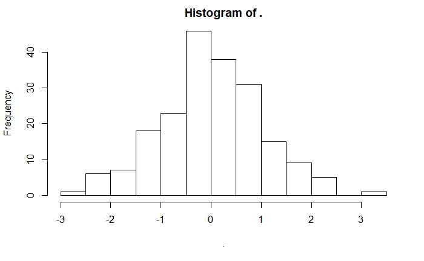

```r
album2$studentized.rediduals %>% hist()
```

#### 고품질 그래프

```r
album2$fitted <- album_sales_3$fitted.values
```

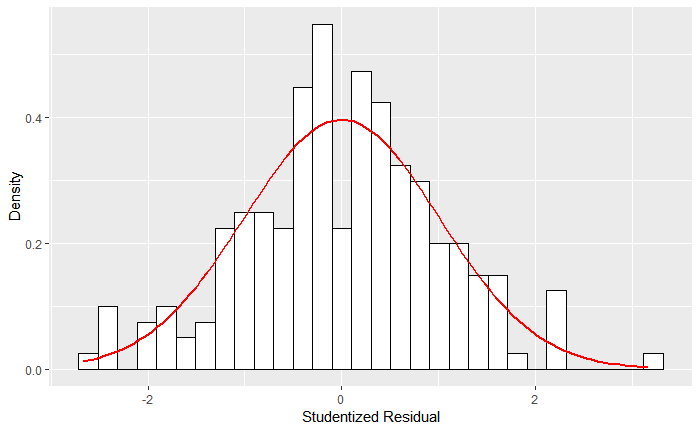

```r
album2 %>%
  ggplot(aes(studentized.rediduals)) + theme(legend.position = 'none') +
  geom_histogram(aes(y = ..density..), colour = 'black', fill = 'white') +
  labs(x = 'Studentized Residual', y = 'Density') -> histogram

histogram +
  stat_function(fun = dnorm,
                args = list(mean = mean(album2$studentized.rediduals, na.rm = T),
                            sd = sd(album2$studentized.rediduals, na.rm = T)),
                            colour = 'red', size = 1) -> p1

p1
```

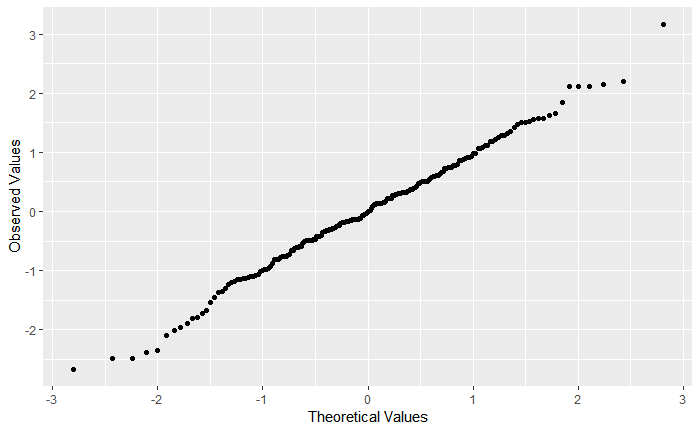

```r
qplot(sample = album2$studentized.rediduals) +
  stat_qq() +
  labs(x = 'Theoretical Values',
       y = 'Observed Values') -> p2

p2
```

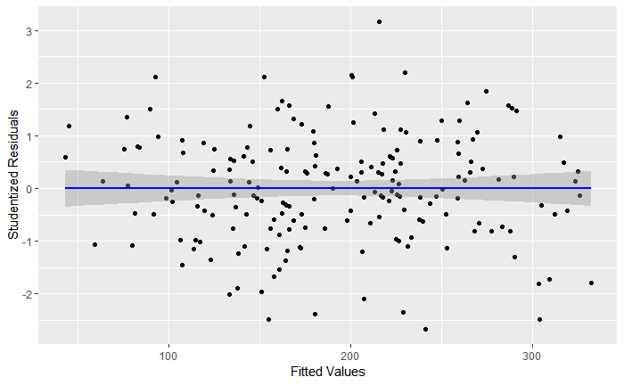

```r
album2 %>%
  ggplot(aes(fitted, studentized.rediduals)) +
  geom_point() +
  geom_smooth(method = 'lm', color = 'Blue') +
  labs(x = 'Fitted Values',
       y = 'Studentized Residuals') -> p3

p3
```

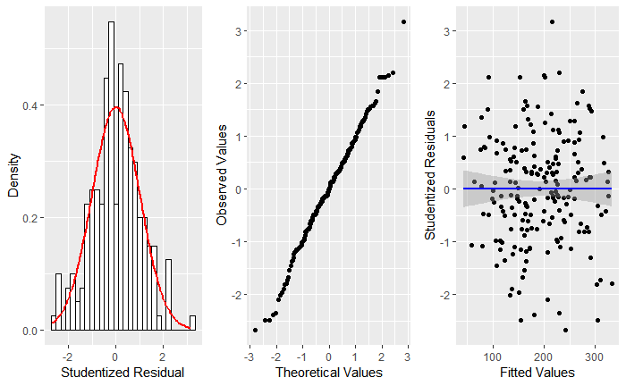

```r
gridExtra::grid.arrange(p1, p2, p3, ncol = 3)
```

#### 7.9.6 가정이 깨졌다면?

- 가정들이 깨졌다면 모형으로 발견한 것들을 표본 이상으로 일반화할 수 없다.
- 잔차들에서 이분산성이나 비정규성이 발견되었다면, 원본 자료를 변환해 볼 수 있다.
- 선형성 가정이 깨졌다면 선형회귀 대신 로지스틱 회귀를 적용해 볼 수있다.
- 마지막으로 강건한 회귀를 시도해 볼 수 있다.

### 7.10 강건한 회귀: 부트스트래핑

- boot 패키지 사용
- Bootstrap을 적용할 함수를 작성

```r
bootReg <- function(formula, data, indices) {
  d <- data[indices, ]
  fit <- lm(formula, data = d)
  return(coef(fit))
}
```

- 다음의 코드를 실행해서 부트스트랩 표본들을 얻는다.

```r
bootResults <- boot(statistic = bootReg,
                    formula = sales ~ adverts + airplay + attract,
                    data = album2,
                    R = 2000)
```

- 신뢰구간을 확인한다.
- R은 bootResults에 담긴 통계량들의 이름을 알지 못하기 때문에, 이름 대신 bootResults 객체 안의 위치를 이용해서 각 통계량을 지정해야 한다. $index = 1$을 지정하면 부트스트랩된 절편의 신뢰구간이 출력된다.

```r
boot.ci(bootResults,
        type = 'bca',  # bias corrected accelerated(신뢰구간의 종류)
        index = 1)
```

```
BOOTSTRAP CONFIDENCE INTERVAL CALCULATIONS
Based on 2000 bootstrap replicates

CALL :
boot.ci(boot.out = bootResults, type = "bca", index = 1)

Intervals :
Level       BCa
95%   (-56.49,   6.80 )
Calculations and Intervals on Original Scale
```

```r
boot.ci(bootResults, type = 'bca', index = 2)
```

```
BOOTSTRAP CONFIDENCE INTERVAL CALCULATIONS
Based on 2000 bootstrap replicates

CALL :
boot.ci(boot.out = bootResults, type = "bca", index = 2)

Intervals :
Level       BCa
95%   ( 0.0710,  0.0981 )
Calculations and Intervals on Original Scale
```

```r
boot.ci(bootResults, type = 'bca', index = 3)
```

```
BOOTSTRAP CONFIDENCE INTERVAL CALCULATIONS
Based on 2000 bootstrap replicates

CALL :
boot.ci(boot.out = bootResults, type = "bca", index = 3)

Intervals :
Level       BCa
95%   ( 2.740,  3.987 )
Calculations and Intervals on Original Scale
```

```r
boot.ci(bootResults, type = 'bca', index = 4)
```

```
BOOTSTRAP CONFIDENCE INTERVAL CALCULATIONS
Based on 2000 bootstrap replicates

CALL :
boot.ci(boot.out = bootResults, type = "bca", index = 4)

Intervals :
Level       BCa
95%   ( 6.73, 15.32 )
Calculations and Intervals on Original Scale
```

```r
confint(album_sales_3)
```

```
                   2.5 %      97.5 %
(Intercept) -60.82960967  7.60369295
adverts       0.07123166  0.09853799
airplay       2.81962186  3.91522848
attract       6.27855218 15.89411823
```

- 부트스트랩 신뢰구간들이 위계적 방식 신뢰구간들과 아주 비슷한 것을 알 수 있다.

### 7.11 다중회귀의 보고

```r
model <- album_sales_3
model.display <- epiDisplay::regress.display(model, crude = T, crude.p.value = T)
model.table <- model.display$table[rownames(model.display$table)!="", ]
kable(model.table, caption = model.display$first.line)
```

|  | crude coeff.(95%CI) | crude P value | adj. coeff.(95%CI) | P(t-test) | P(F-test) |
| --- | --- | --- | --- | --- | --- |
| adverts (cont. var.) | 0.1 (0.08,0.12) | < 0.001 | 0.08 (0.07,0.1) | < 0.001 | < 0.001 |
| airplay (cont. var.) | 3.94 (3.2,4.68) | < 0.001 | 3.37 (2.82,3.92) | < 0.001 | < 0.001 |
| attract (cont. var.) | 18.86 (11.2,26.52) | < 0.001 | 11.09 (6.28,15.89) | < 0.001 | < 0.001 |

### 7.12 범주형 예측변수와 다중회귀

- 회귀분석은 예측변수가 연속변수이거나 범주가 두 개 뿐인 범주형변수라는 가정을 깔고 있다.
- 한 변수가 연속변수이고 다른 한 변수가 0과 1로 부호화된 두 범주를 가진 범주형 변수일때 그 두 변수의 피어슨 상관계수 r은 곧 점이연 상관계수이다.
- 회귀분석을 위해 두 범주를 0과 1이라는 수치들로 부호화해야 한다.

#### 7.12.1 가변수를 이용한 범주 부호화

- dummy variable
- 1. 부호화하려는 그룹의 수에서 1을 뺀다.
- 2. 단계 1에서 구한 개수만큼 새 변수를 만든다. 이들이 가변수들이다.
- 3. 그룹 중 하나를 기저(baseline) 그룹으로 선택한다. 보통의 경우 대조군을 기저 그룹으로 선택하지만, 특정한 가설이 없는 경우라면 사람들의 대다수를 대표하는 그룹을 기저 그룹으로 선택해야 한다.
- 4. 모든 가변수에 대해, 기저 그룹에 그룹 값 0을 배정한다.
- 5. 첫 가변수에 대해 값 1을 배정하고 나머지에는 0을 배정한다. 두번째부터 나머지 가변수에서 이같이 반복한다.

|  | 가변수1 | 가변수2 | 가변수 3 |
| --- | --- | --- | --- |
| Crusty | 1 | 0 | 0 |
| Indie Kid | 0 | 1 | 0 |
| Metaller | 0 | 0 | 1 |
| No Musical Affiliation | 0 | 0 | 0 |

```r
gfr <- read.delim(file = 'GlastonburyFestivalRegression.dat', header = T)
gfr %>% head(10)
```

|  | ticknumb | music | day1 | day2 | day3 | change |
| --- | --- | --- | --- | --- | --- | --- |
| 1 | 2111 | Metaller | 2.65 | 1.35 | 1.61 | -1.04 |
| 2 | 2229 | Crusty | 0.97 | 1.41 | 0.29 | -0.68 |
| 3 | 2338 | No Musical Affiliation | 0.84 | NA | NA | NA |
| 4 | 2384 | Crusty | 3.03 | NA | NA | NA |
| 5 | 2401 | No Musical Affiliation | 0.88 | 0.08 | NA | NA |
| 6 | 2405 | Crusty | 0.85 | NA | NA | NA |
| 7 | 2467 | Indie Kid | 1.56 | NA | NA | NA |
| 8 | 2478 | Indie Kid | 3.02 | NA | NA | NA |
| 9 | 2490 | Crusty | 2.29 | NA | NA | NA |
| 10 | 2504 | No Musical Affiliation | 1.11 | 0.44 | 0.55 | -0.56 |

```r
gfr$music %>% unique()
```

```
[1] Metaller               Crusty                 No Musical Affiliation
[4] Indie Kid
Levels: Crusty Indie Kid Metaller No Musical Affiliation
```

```r
contrasts(gfr$music) <- contr.treatment(4, base = 4)
```

```r
gfr$music %>% attr(., 'contrasts')
```

```
                       1 2 3
Crusty                 1 0 0
Indie Kid              0 1 0
Metaller               0 0 1
No Musical Affiliation 0 0 0
```

#### 7.12.2 가변수를 이용한 회귀분석

```r
glastonburyModel <- lm(change ~ music, data = gfr)
```

```r
glastonburyModel %>% summary()
```

```
Call:
lm(formula = change ~ music, data = gfr)

Residuals:
     Min       1Q   Median       3Q      Max
-1.82569 -0.50489  0.05593  0.42430  1.59431

Coefficients:
            Estimate Std. Error t value Pr(>|t|)
(Intercept) -0.55431    0.09036  -6.134 1.15e-08 ***
music1      -0.41152    0.16703  -2.464   0.0152 *
music2      -0.40998    0.20492  -2.001   0.0477 *
music3       0.02838    0.16033   0.177   0.8598
---
Signif. codes:  0 ‘***’ 0.001 ‘**’ 0.01 ‘*’ 0.05 ‘.’ 0.1 ‘ ’ 1

Residual standard error: 0.6882 on 119 degrees of freedom
  (687 observations deleted due to missingness)
Multiple R-squared:  0.07617,   Adjusted R-squared:  0.05288
F-statistic:  3.27 on 3 and 119 DF,  p-value: 0.02369
```

- Multiple R-squared: 0.07617: 위생 점수 변화량의 변동의 7.6%는 참가자의 음악 취향으로 설명된다.
- music1(Crusty) -0.41152(beta, Estimate) 0.16703(Std. Error) -2.464(t value) 0.0152(Pr) * : -0.41152(beta, Estimate)값은 가변수가 0에서 1로 변할 때의 위생 점수의 변화량에 해당한다. 이 값은 음악 취향이 없는 사람의 위생 점수의 변화와 Crusty 그룹에 속하는 사람의 위생 점수의 변화의 실제 차이를 나타낸다.
- 실제로 네 그룹의 평균을 구해보면 위의 사실을 알 수 있다.

```r
gfr %>%
  group_by(music) %>%
  summarise(mean.change = mean(change, na.rm = T)) %>%
  mutate(mean.change = round(mean.change, 3))
```

| music | mean.change |
| --- | --- |
| Crusty | -0.966 |
| Indie Kid | -0.964 |
| Metaller | -0.526 |
| No Musical Affiliation | -0.554 |

```r
(-.966) - (-0.554)
```

```
[1] -0.412
```

- Crusty 그룹의 위생 점수 변화가 무취향 그룹의 위생 점수 변화보다 크다. 따라서 베타 값들은 기저 범주로 선택한 그룹과 다른 그룹들 사이의 상대적 차이를 말해준다.
- t-검정통계량이 유의하다는 것은 1이라는 수치로 부호화된 그룹이 기저 그룹과 유의하게 다르다는 것이다.(Crusty 그룹의 위생 점수가 유의한 수준으로 더 많이 감소했다.)
- 마지막 가변수의 경우 t 검정은 유의하지 않다. 무취향에서 메탈러로 범주가 변해도 위생 점수 변화량은 변화가 없다고 할 수 있다.